# Iris classification

Classify Lily species based on features: sepal_length, sepal_width, petal_length, petal_width  
using Supervised and Unsuperized approaches to classification  
1) First run exploratiory data analysis to explore, get a feel for the data to inform modeling  
2) Select and implement models and assess performance

Reference: http://archive.ics.uci.edu/ml/datasets/Iris

### Load libraries and read the dataset

```python
# load libraries

#!pip install scikit-learn==0.23.1
#!pip install matplotlib==3.1.2

import pandas as pd
import numpy as np
import matplotlib.pyplot as plt
import seaborn as sns
```

```python
# read csv file
data = pd.read_csv('./data/irisdata.csv')
```

```python
# add columns (only if the columns are missing)
data.columns = ['sepal_length','sepal_width','petal_length','petal_width','species']
data.columns
```

```
Index(['sepal_length', 'sepal_width', 'petal_length', 'petal_width',
       'species'],
      dtype='object')
```

### Peak at the data

```python
print (data.shape, '\n')

data.info()
```

```
(149, 5)

<class 'pandas.core.frame.DataFrame'>
RangeIndex: 149 entries, 0 to 148
Data columns (total 5 columns):
 #   Column        Non-Null Count  Dtype
---  ------        --------------  -----
 0   sepal_length  149 non-null    float64
 1   sepal_width   149 non-null    float64
 2   petal_length  149 non-null    float64
 3   petal_width   149 non-null    float64
 4   species       149 non-null    object
dtypes: float64(4), object(1)
memory usage: 5.9+ KB
```

```python
data.head()
```

|  | sepal_length | sepal_width | petal_length | petal_width | species |
| --- | --- | --- | --- | --- | --- |
| 0 | 4.9 | 3.0 | 1.4 | 0.2 | Iris-setosa |
| 1 | 4.7 | 3.2 | 1.3 | 0.2 | Iris-setosa |
| 2 | 4.6 | 3.1 | 1.5 | 0.2 | Iris-setosa |
| 3 | 5.0 | 3.6 | 1.4 | 0.2 | Iris-setosa |
| 4 | 5.4 | 3.9 | 1.7 | 0.4 | Iris-setosa |

```python
data.tail()
```

|  | sepal_length | sepal_width | petal_length | petal_width | species |
| --- | --- | --- | --- | --- | --- |
| 144 | 6.7 | 3.0 | 5.2 | 2.3 | Iris-virginica |
| 145 | 6.3 | 2.5 | 5.0 | 1.9 | Iris-virginica |
| 146 | 6.5 | 3.0 | 5.2 | 2.0 | Iris-virginica |
| 147 | 6.2 | 3.4 | 5.4 | 2.3 | Iris-virginica |
| 148 | 5.9 | 3.0 | 5.1 | 1.8 | Iris-virginica |

- 149 observations, 5 columns, all numeric except species which is categorical
- species is the labeled column specifying the lily species given input features (sepal_length, sepal_width petal_length, petal_width)
- dataset looks to be ordered by species type

## Exploratory Data Analysis

Understand the class distribution of lily types in the dataset

```python
data['species'].unique()
```

```
array(['Iris-setosa', 'Iris-versicolor', 'Iris-virginica'], dtype=object)
```

```python
# class distributions (2 ways)
print(data["species"].value_counts(), '\n')

print(data.groupby('species')['species'].count())
```

```
Iris-virginica     50
Iris-versicolor    50
Iris-setosa        49
Name: species, dtype: int64

species
Iris-setosa        49
Iris-versicolor    50
Iris-virginica     50
Name: species, dtype: int64
```

- 3 class types: Iris-setosa, Iris-versicolor, Iris-virginica
- class distributions are nearly even

### Preprocessing, cleansing

- Check for missing values and process as needed
- Check duplicate rows

```python
# check for nan
data.isnull().values.any()
```

```
False
```

no NaN (null, empty) values

Next check for duplicate rows

```python
# Select all duplicate rows based on all columns  (keep = false)
duplicateRows = data[data.duplicated(keep=False)]

if len(duplicateRows.any()):
  sortedDups = duplicateRows.sort_values(by=data.columns.to_list()).head()
  print(f'duplicate rows\n {sortedDups}')
```

```
duplicate rows
      sepal_length  sepal_width  petal_length  petal_width         species
8             4.9          3.1           1.5          0.1     Iris-setosa
33            4.9          3.1           1.5          0.1     Iris-setosa
36            4.9          3.1           1.5          0.1     Iris-setosa
100           5.8          2.7           5.1          1.9  Iris-virginica
141           5.8          2.7           5.1          1.9  Iris-virginica
```

- We have some duplicates (2 for Iris-setosa) and (1 for Iris-virginica)
- We can drop duplicates as follows

```python
print (f'dataset size before dropping duplicates {len(data)}')

# drop duplicates, defaults to keep=first : Drop duplicates except for the first occurrence.
data = data.drop_duplicates()

print (f'dataset size after dropping duplicates {len(data)}')
```

```
dataset size before dropping duplicates 149
dataset size after dropping duplicates 146
```

### Statistical summary

**statistical summary of all attributes**

```python
data.describe().round()
```

|  | sepal_length | sepal_width | petal_length | petal_width |
| --- | --- | --- | --- | --- |
| count | 146.0 | 146.0 | 146.0 | 146.0 |
| mean | 6.0 | 3.0 | 4.0 | 1.0 |
| std | 1.0 | 0.0 | 2.0 | 1.0 |
| min | 4.0 | 2.0 | 1.0 | 0.0 |
| 25% | 5.0 | 3.0 | 2.0 | 0.0 |
| 50% | 6.0 | 3.0 | 4.0 | 1.0 |
| 75% | 6.0 | 3.0 | 5.0 | 2.0 |
| max | 8.0 | 4.0 | 7.0 | 2.0 |

- range of sepal_length is from 4-8 with an avg of 6
- range of sepal_width is from 2-4 with an avg of 3
- range of petal_length is from 1-7 with an avg of 4
- range of petal_width is from 0-2 with an avg of 1

Observe different ranges between width and length, with length values a bit greater than width. However, the scale is the same, measured in cm.

**statistical summary by class variable**

```python
species = data.groupby('species').describe().round()

# transposed index and columns.
species.transpose()
```

|  | species | Iris-setosa | Iris-versicolor | Iris-virginica |
| --- | --- | --- | --- | --- |
| sepal_length | count | 47.0 | 50.0 | 49.0 |
|  | mean | 5.0 | 6.0 | 7.0 |
|  | std | 0.0 | 1.0 | 1.0 |
|  | min | 4.0 | 5.0 | 5.0 |
|  | 25% | 5.0 | 6.0 | 6.0 |
|  | 50% | 5.0 | 6.0 | 6.0 |
|  | 75% | 5.0 | 6.0 | 7.0 |
|  | max | 6.0 | 7.0 | 8.0 |
| sepal_width | count | 47.0 | 50.0 | 49.0 |
|  | mean | 3.0 | 3.0 | 3.0 |
|  | std | 0.0 | 0.0 | 0.0 |
|  | min | 2.0 | 2.0 | 2.0 |
|  | 25% | 3.0 | 3.0 | 3.0 |
|  | 50% | 3.0 | 3.0 | 3.0 |
|  | 75% | 4.0 | 3.0 | 3.0 |
|  | max | 4.0 | 3.0 | 4.0 |
| petal_length | count | 47.0 | 50.0 | 49.0 |
|  | mean | 1.0 | 4.0 | 6.0 |
|  | std | 0.0 | 0.0 | 1.0 |
|  | min | 1.0 | 3.0 | 4.0 |
|  | 25% | 1.0 | 4.0 | 5.0 |
|  | 50% | 2.0 | 4.0 | 6.0 |
|  | 75% | 2.0 | 5.0 | 6.0 |
|  | max | 2.0 | 5.0 | 7.0 |
| petal_width | count | 47.0 | 50.0 | 49.0 |
|  | mean | 0.0 | 1.0 | 2.0 |
|  | std | 0.0 | 0.0 | 0.0 |
|  | min | 0.0 | 1.0 | 1.0 |
|  | 25% | 0.0 | 1.0 | 2.0 |
|  | 50% | 0.0 | 1.0 | 2.0 |
|  | 75% | 0.0 | 2.0 | 2.0 |
|  | max | 1.0 | 2.0 | 2.0 |

### Visualization

#### Univariate plots

on single features: sepal-length, sepal-width, petal-length, petal-width

**visualizations: bar graphs, histogram/desity plots and boxplots**

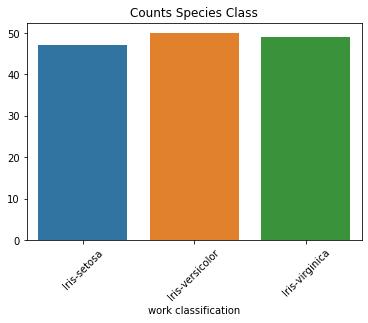

```python
ax=sns.countplot(data = data, x = "species")
ax.set_title('Counts Species Class')
plt.xticks(rotation=45)
ax.set(xlabel='work classification', ylabel='');
```

as observed earlier, the class distribution by species is nearly equal

```python
# exclude species (target) from graphs (all rows, first 4 columns)
df = data.iloc[:, :4]
```

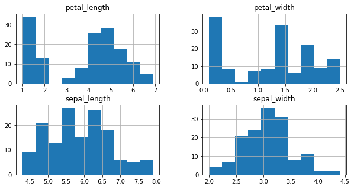

```python
df.hist(figsize = (10,5))
plt.show()
```

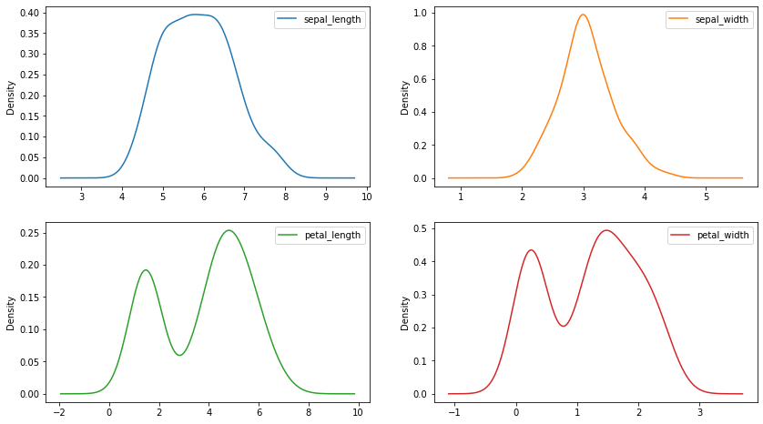

```python
# density plots
df.plot(figsize=(14,8), kind='density', subplots=True, layout=(2,2), sharex=False)
plt.show()
```

petal length, petal width are multimodal distribution (2 peaks) vs sepal length and sepal width which has a more normal distribution

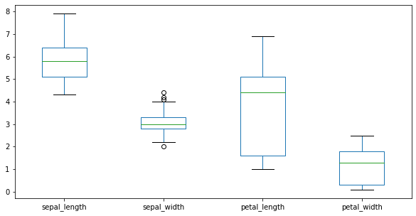

```python
#df.plot(figsize=(10,5), kind='box', subplots=True, layout=(2,2), sharex=False, sharey=False)
df.plot(figsize=(10,5), kind='box')
plt.show()
```

sepal width has outliers (extreme values) on both the low and high extremities.  
petal length and width are left skewed.

#### Multivariate plots

relationship between features

scatter plots, correlation matrix, etc

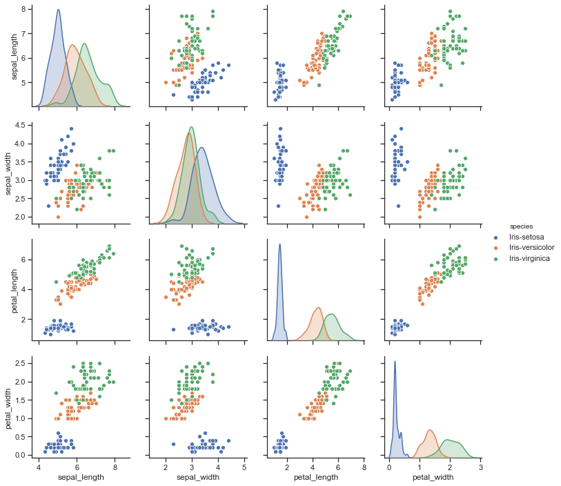

```python
sns.set(style='ticks', color_codes=True)
sns.pairplot(data, hue='species', diag_kind = 'kde');
```

We can observe linear relationships, next lets display the correlation matrix

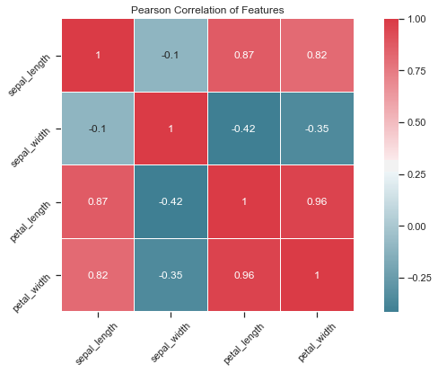

```python
# correlation
corr = df.corr()
#corr.style.background_gradient(cmap='coolwarm')

f, ax = plt.subplots(figsize=(12, 6))

# generate a custom diverging colormap
cmap = sns.diverging_palette(220,10, as_cmap=True)

sns.heatmap(corr, cmap=cmap, annot=True, square=True, ax=ax,  linewidth = 0.1)
plt.title('Pearson Correlation of Features')
plt.yticks(rotation=45)
plt.xticks(rotation=45);
```

strong positive correlation between:

- petal length and sepal length (0.87),
- petal width and sepal length (0.82),
- petal length and petal width (.96)

We can visualize these linear relationships using scatter plots

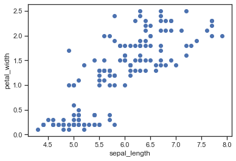

```python
plt.scatter(y=data['petal_width'], x=data['sepal_length'], marker='o');
plt.xlabel('sepal_length')
plt.ylabel('petal_width');
```

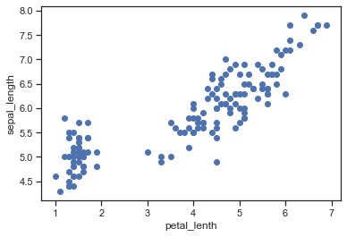

```python
plt.scatter(y=data['sepal_length'], x=data['petal_length'], marker='o');
plt.xlabel('petal_lenth')
plt.ylabel('sepal_length');
```

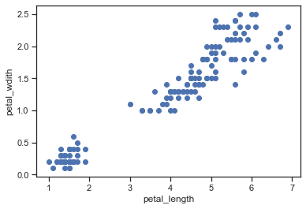

```python
plt.scatter(y=data['petal_width'], x=data['petal_length'], marker='o');
plt.xlabel('petal_length')
plt.ylabel('petal_wdith');
```

We can see the strongest correlation between petal_width and petal_length

**categorical variables plots**

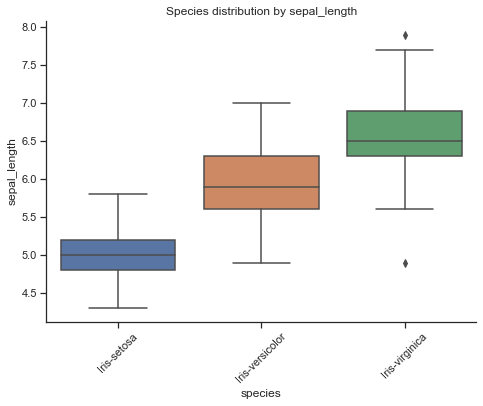

```python
sns.catplot(x="species", y="sepal_length", kind="box", data=data,
           height=5, aspect=11/8)
plt.title('Species distribution by sepal_length')
plt.xticks(rotation=45);
```

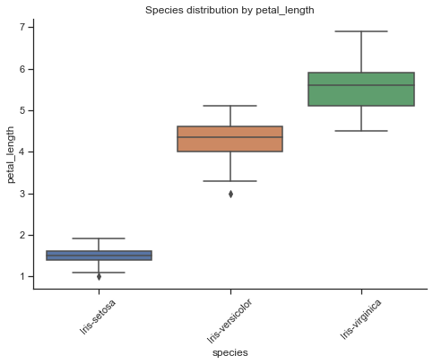

```python
sns.catplot(x="species", y="petal_length", kind="box", data=data,
           height=5, aspect=11/8)
plt.title('Species distribution by petal_length')
plt.xticks(rotation=45);
```

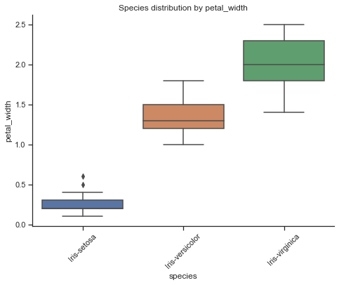

```python
sns.catplot(x="species", y="petal_width", kind="box", data=data,
           height=5, aspect=11/8)
plt.title('Species distribution by petal_width')
plt.xticks(rotation=45);
```

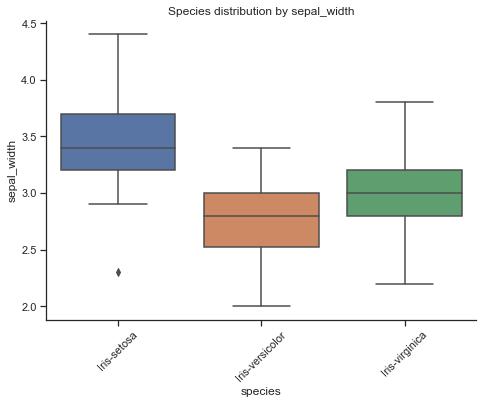

```python
sns.catplot(x="species", y="sepal_width", kind="box", data=data,
           height=5, aspect=11/8)
plt.title('Species distribution by sepal_width')
plt.xticks(rotation=45);
```